# Homework - Chapter 8

Barret Miller

March 7, 2016

### 8.4.7

```r
library(MASS)
library(randomForest)
```

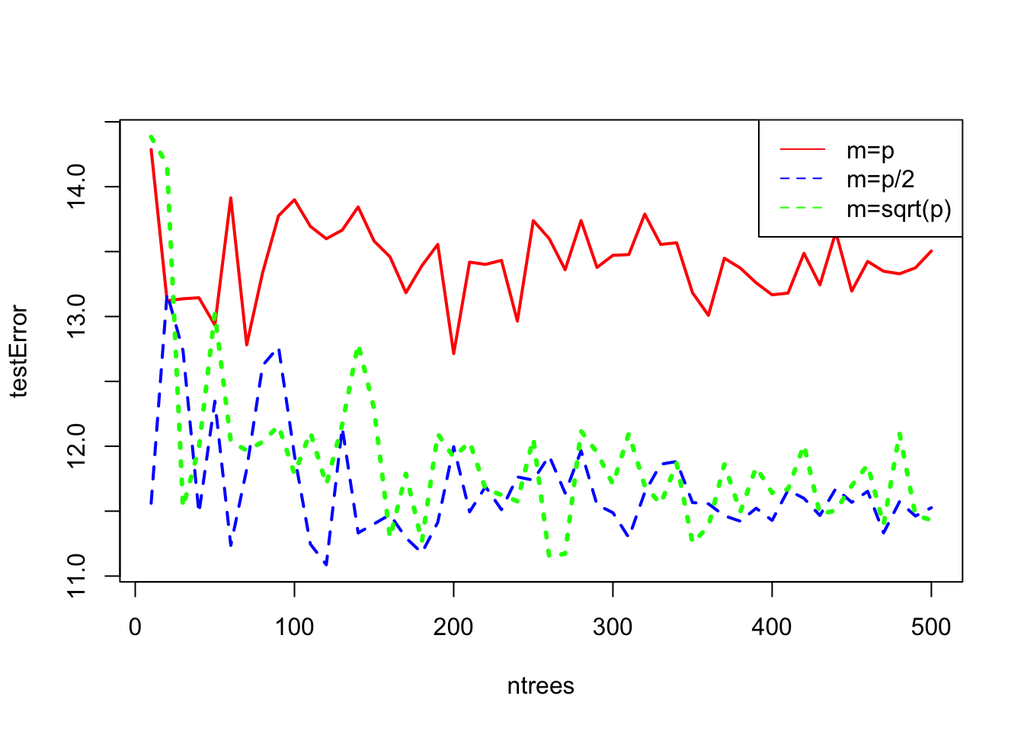

```r
attach(Boston)
data(Boston)

set.seed(1)
train = sample(nrow(Boston),nrow(Boston)/2)

ntrees = seq(10,500,by=10)
nvars = c(ncol(Boston)-1, ceiling((ncol(Boston)-1)/2), ceiling(sqrt(ncol(Boston)-1)))

testError = matrix(NA,ncol=3,nrow=50)
for(i in 1:length(nvars)){
   nv = nvars[i]
   for(j in 1:length(ntrees)){
      nt = ntrees[j]
      rf = randomForest(medv~.,data=Boston,subset=train,mtry=nv,ntree=nt)
      yhat = predict(rf,newdata=Boston[-train,])
      #print(paste(i,j))
      testError[j,i] = mean((yhat-Boston[-train,"medv"])^2)
   }
}

matplot(ntrees,testError,col=c("red","blue","green"),type="l",lwd=c(2,2,3))
legend("topright",legend=c("m=p", "m=p/2", paste0("m=",expression(sqrt(p)))), col=c("red","blue","green"),lty = c(1,2,2))
```

An alternative approach would be to just use the built-in features of the randomForest library, which allow you to pass in a test set, and it will automatically return the test MSE vector. This returns a value for every number of trees incrementing by 1, instead of by 10s as I did. Also it is much faster, so it must have some optimizations. I pulled this code straight from: https://rpubs.com/ppaquay/65564 From the documentation for randomForest:

> If xtest is given, prediction of the test set is done “in place” as the trees are grown.

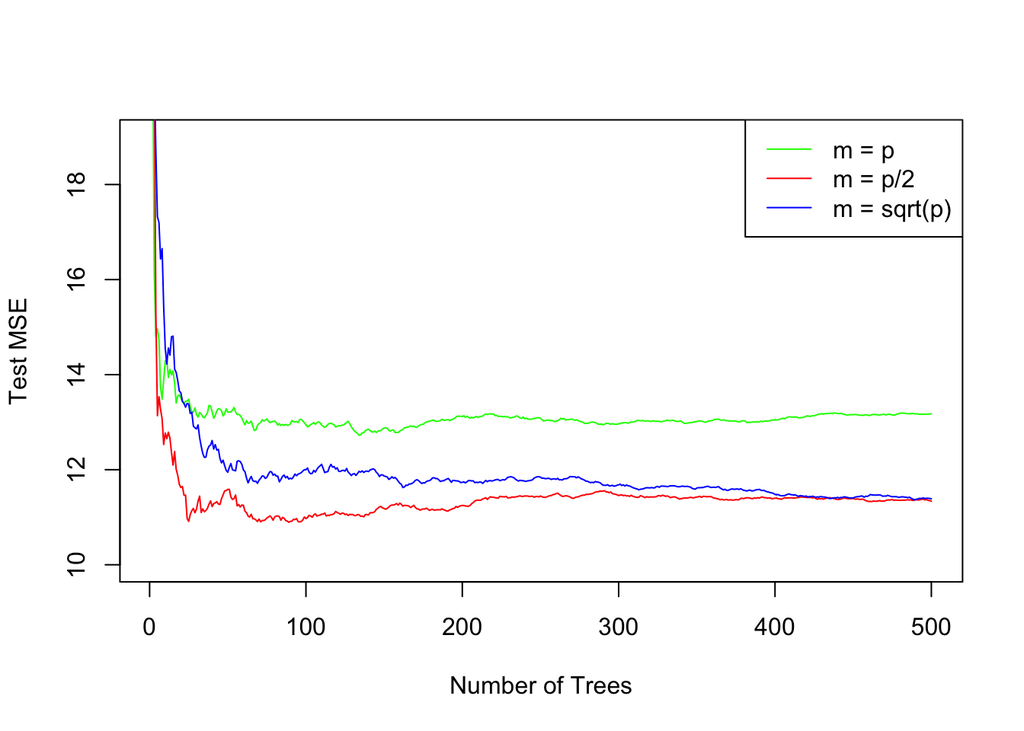

```r
set.seed(1)
train <- sample(1:nrow(Boston), nrow(Boston) / 2)
Boston.train <- Boston[train, -14]
Boston.test <- Boston[-train, -14]
Y.train <- Boston[train, 14]
Y.test <- Boston[-train, 14]
rf.boston1 <- randomForest(Boston.train, y = Y.train, xtest = Boston.test, ytest = Y.test, mtry = ncol(Boston) - 1, ntree = 500)
rf.boston2 <- randomForest(Boston.train, y = Y.train, xtest = Boston.test, ytest = Y.test, mtry = (ncol(Boston) - 1) / 2, ntree = 500)
rf.boston3 <- randomForest(Boston.train, y = Y.train, xtest = Boston.test, ytest = Y.test, mtry = sqrt(ncol(Boston) - 1), ntree = 500)
plot(1:500, rf.boston1$test$mse, col = "green", type = "l", xlab = "Number of Trees", ylab = "Test MSE", ylim = c(10, 19))
lines(1:500, rf.boston2$test$mse, col = "red", type = "l")
lines(1:500, rf.boston3$test$mse, col = "blue", type = "l")
legend("topright", c("m = p", "m = p/2", "m = sqrt(p)"), col = c("green", "red", "blue"), cex = 1, lty = 1)
```

### 8.4.8

8. In the lab, a classification tree was applied to the Carseats data set af- ter converting Sales into a qualitative response variable. Now we will seek to predict Sales using regression trees and related approaches, treating the response as a quantitative variable.
1. Split the data set into a training set and a test set.
2. Fit a regression tree to the training set. Plot the tree, and inter- pret the results. What test MSE do you obtain?
3. Use cross-validation in order to determine the optimal level of tree complexity. Does pruning the tree improve the test MSE?

```r
library(ISLR)
library(tree)
data(Carseats)
attach(Carseats)
set.seed(1)
train = sample(nrow(Carseats),nrow(Carseats)/2)
test.y = Carseats[-train,"Sales"]
tree.carseats = tree(Sales~.,data=Carseats,subset=train)
summary.carseats = summary(tree.carseats)
summary.carseats
```

```
##
## Regression tree:
## tree(formula = Sales ~ ., data = Carseats, subset = train)
## Variables actually used in tree construction:
## [1] "ShelveLoc"   "Price"       "Age"         "Advertising" "Income"
## [6] "CompPrice"
## Number of terminal nodes:  18
## Residual mean deviance:  2.36 = 429.5 / 182
## Distribution of residuals:
##    Min. 1st Qu.  Median    Mean 3rd Qu.    Max.
## -4.2570 -1.0360  0.1024  0.0000  0.9301  3.9130
```

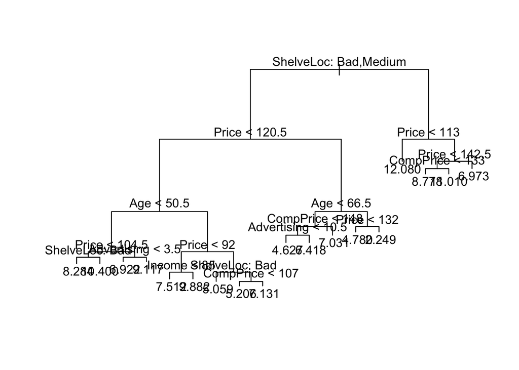

```r
plot(tree.carseats)
text(tree.carseats,pretty=0)
```

```r
tree.pred = predict(tree.carseats, newdata=Carseats[-train,])
mean((tree.pred-test.y)^2)
```

```
## [1] 4.148897
```

```r
cv.carseats = cv.tree(tree.carseats)
names(cv.carseats)
```

```
## [1] "size"   "dev"    "k"      "method"
```

```r
cv.carseats
```

```
## $size
##  [1] 18 17 16 15 14 12 11 10  9  8  7  6  5  4  3  1
##
## $dev
##  [1] 1094.537 1085.178 1089.409 1069.294 1069.294 1075.806 1044.469
##  [8] 1039.212 1039.212 1041.308 1043.459 1064.162 1119.046 1120.344
## [15] 1270.012 1560.273
##
## $k
##  [1]      -Inf  15.48181  15.53599  18.69038  18.74886  21.05038  23.79480
##  [8]  25.78579  26.01210  30.10435  32.74801  53.28569  72.33061  78.19599
## [15] 141.73781 251.22901
##
## $method
## [1] "deviance"
##
## attr(,"class")
## [1] "prune"         "tree.sequence"
```

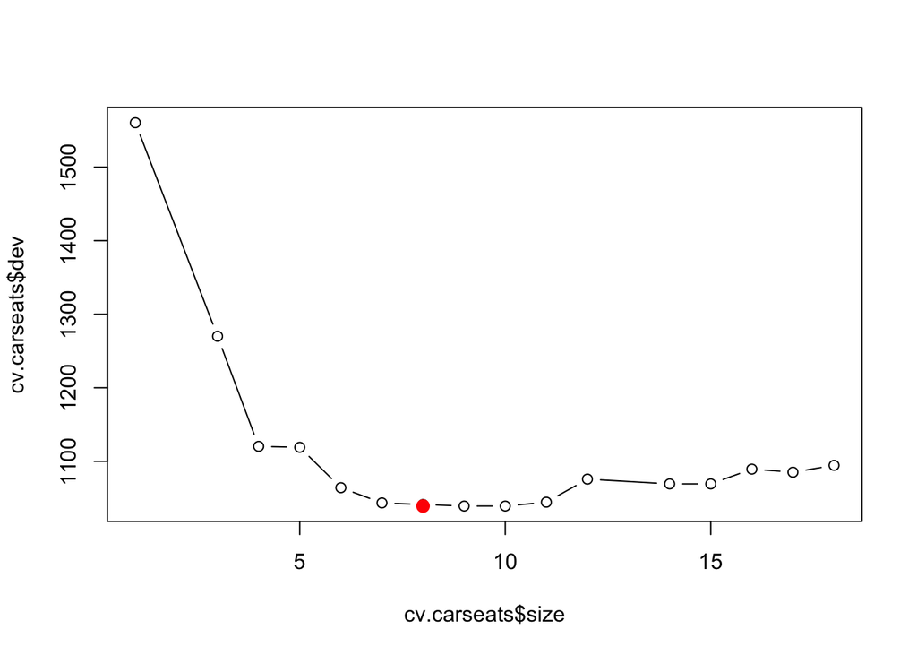

```r
plot(cv.carseats$size, cv.carseats$dev,type="b")
points(which.min(cv.carseats$dev),cv.carseats$dev[which.min(cv.carseats$dev)],col="red",pch=19,cex=1.25)
```

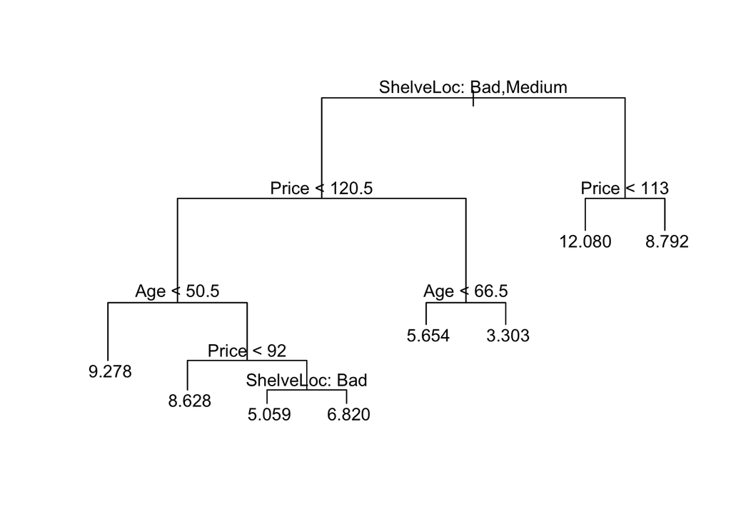

```r
prune.carseats = prune.tree(tree.carseats,best = which.min(cv.carseats$dev))
plot(prune.carseats)
text(prune.carseats,pretty=0)
```

```r
prune.pred = predict(prune.carseats, Carseats[-train,])
mean((prune.pred-test.y)^2)
```

```
## [1] 5.09085
```

4. Use the bagging approach in order to analyze this data. What test MSE do you obtain? Use the importance() function to de- termine which variables are most important.

```r
library(randomForest)
set.seed(1)
bag.carseats = randomForest(Sales~.,data=Carseats,mtry=10,subset=train,importance=T)
bag.carseats
```

```
##
## Call:
##  randomForest(formula = Sales ~ ., data = Carseats, mtry = 10,      importance = T, subset = train)
##                Type of random forest: regression
##                      Number of trees: 500
## No. of variables tried at each split: 10
##
##           Mean of squared residuals: 2.825834
##                     % Var explained: 62.98
```

```r
yhat.bag = predict(bag.carseats,newdata=Carseats[-train,])
mean((yhat.bag - test.y)^2)
```

```
## [1] 2.554292
```

```r
importance(bag.carseats)
```

```
##               %IncMSE IncNodePurity
## CompPrice   14.032030    129.568747
## Income       5.523038     75.448682
## Advertising 13.571285    131.246840
## Population   1.968853     63.042648
## Price       56.863812    504.158108
## ShelveLoc   44.720455    323.055042
## Age         22.225468    194.915976
## Education    4.823966     40.810991
## Urban       -1.902185      8.746566
## US           6.632887     14.599565
```

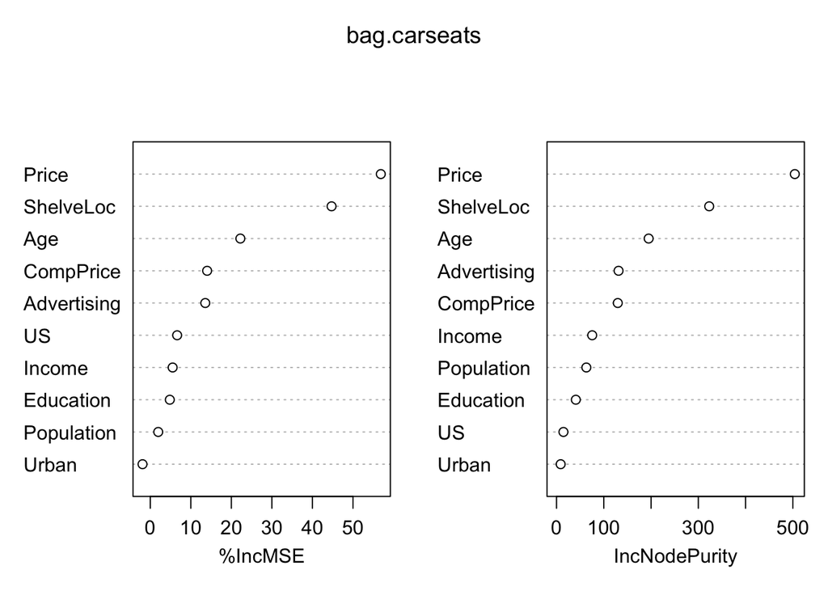

```r
varImpPlot(bag.carseats)
```

5. Use random forests to analyze this data. What test MSE do you obtain? Use the importance() function to determine which vari- ables are most important. Describe the effect of m, the number of variables considered at each split, on the error rate obtained.

```r
set.seed(1)
rf5.carseats = randomForest(Sales~.,data=Carseats,mtry=5,subset=train,importance=T)
rf3.carseats = randomForest(Sales~.,data=Carseats,mtry=3,subset=train,importance=T)
rf5.carseats
```

```
##
## Call:
##  randomForest(formula = Sales ~ ., data = Carseats, mtry = 5,      importance = T, subset = train)
##                Type of random forest: regression
##                      Number of trees: 500
## No. of variables tried at each split: 5
##
##           Mean of squared residuals: 2.967775
##                     % Var explained: 61.12
```

```r
rf3.carseats
```

```
##
## Call:
##  randomForest(formula = Sales ~ ., data = Carseats, mtry = 3,      importance = T, subset = train)
##                Type of random forest: regression
##                      Number of trees: 500
## No. of variables tried at each split: 3
##
##           Mean of squared residuals: 3.362705
##                     % Var explained: 55.94
```

```r
yhat5.rf = predict(rf5.carseats,newdata=Carseats[-train,])
yhat3.rf = predict(rf3.carseats,newdata=Carseats[-train,])

mean((yhat5.rf-test.y)^2)
```

```
## [1] 2.835178
```

```r
mean((yhat3.rf-test.y)^2)
```

```
## [1] 3.287469
```

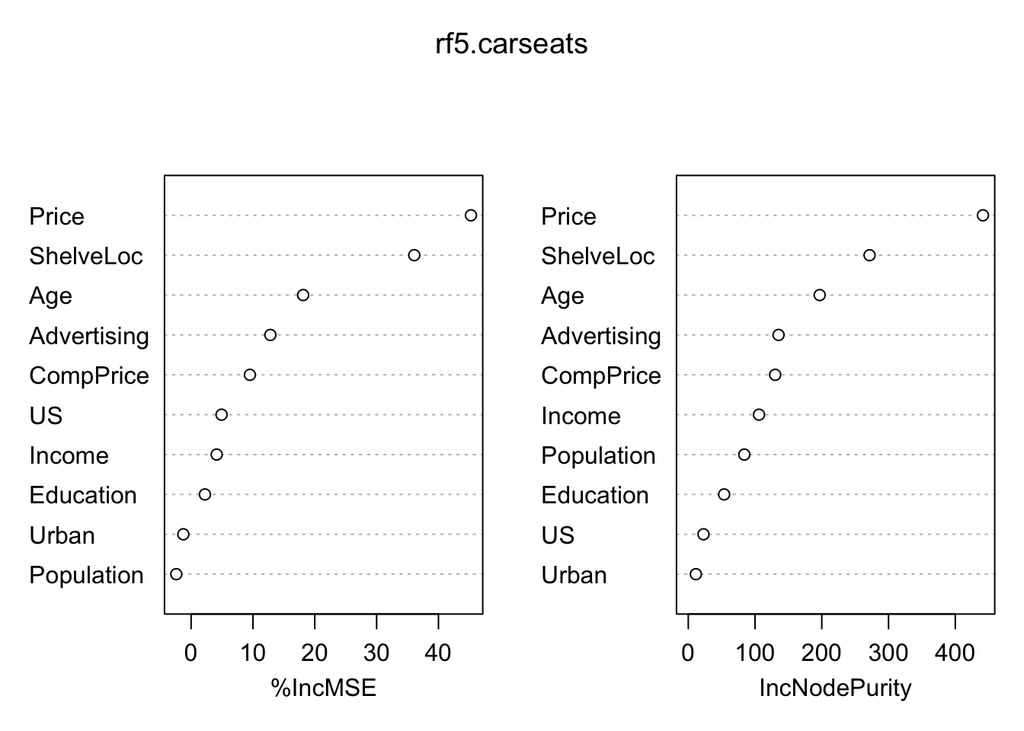

```r
par(mfrow=c(2,2))
varImpPlot(rf5.carseats)
```

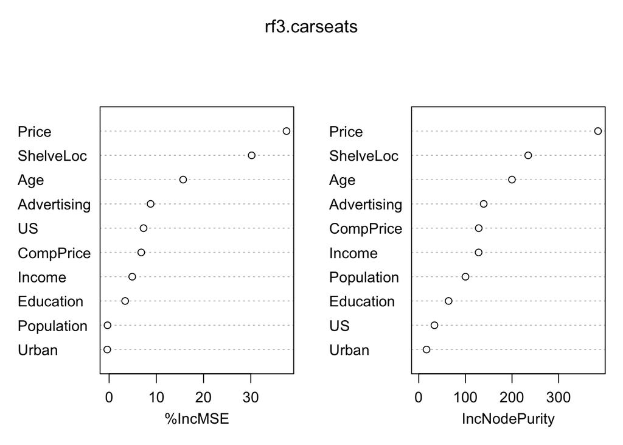

```r
varImpPlot(rf3.carseats)
```

### 8.4.9

9. This problem involves the OJ data set which is part of the ISLR package.
1. Create a training set containing a random sample of 800 observations, and a test set containing the remaining observations.
2. Fit a tree to the training data, with Purchase as the response and the other variables as predictors. Use the summary() function to produce summary statistics about the tree, and describe the results obtained. What is the training error rate? How many terminal nodes does the tree have?

```r
library(ISLR)

data(OJ)
attach(OJ)

set.seed(1)
train = sample(1:nrow(OJ),800)
OJ.train = OJ[train,]
OJ.test = OJ[-train,]

tree.OJ = tree(Purchase~.,OJ.train)
summary(tree.OJ)
```

```
##
## Classification tree:
## tree(formula = Purchase ~ ., data = OJ.train)
## Variables actually used in tree construction:
## [1] "LoyalCH"       "PriceDiff"     "SpecialCH"     "ListPriceDiff"
## Number of terminal nodes:  8
## Residual mean deviance:  0.7305 = 578.6 / 792
## Misclassification error rate: 0.165 = 132 / 800
```

```r
tree.OJ
```

```
## node), split, n, deviance, yval, (yprob)
##       * denotes terminal node
##
##  1) root 800 1064.00 CH ( 0.61750 0.38250 )
##    2) LoyalCH < 0.508643 350  409.30 MM ( 0.27143 0.72857 )
##      4) LoyalCH < 0.264232 166  122.10 MM ( 0.12048 0.87952 )
##        8) LoyalCH < 0.0356415 57   10.07 MM ( 0.01754 0.98246 ) *
##        9) LoyalCH > 0.0356415 109  100.90 MM ( 0.17431 0.82569 ) *
##      5) LoyalCH > 0.264232 184  248.80 MM ( 0.40761 0.59239 )
##       10) PriceDiff < 0.195 83   91.66 MM ( 0.24096 0.75904 )
##         20) SpecialCH < 0.5 70   60.89 MM ( 0.15714 0.84286 ) *
##         21) SpecialCH > 0.5 13   16.05 CH ( 0.69231 0.30769 ) *
##       11) PriceDiff > 0.195 101  139.20 CH ( 0.54455 0.45545 ) *
##    3) LoyalCH > 0.508643 450  318.10 CH ( 0.88667 0.11333 )
##      6) LoyalCH < 0.764572 172  188.90 CH ( 0.76163 0.23837 )
##       12) ListPriceDiff < 0.235 70   95.61 CH ( 0.57143 0.42857 ) *
##       13) ListPriceDiff > 0.235 102   69.76 CH ( 0.89216 0.10784 ) *
##      7) LoyalCH > 0.764572 278   86.14 CH ( 0.96403 0.03597 ) *
```

We get to node 7 by first having a LoyalCH >= 0.508643, then by having a LoyalCH >=0.764572. If both of those things are true, then there’s a greater than 96% probability that CH will be purchased. There were 278 observations in this branch/terminal node with an 86.14 deviance. (d) Create a plot of the tree, and interpret the results.

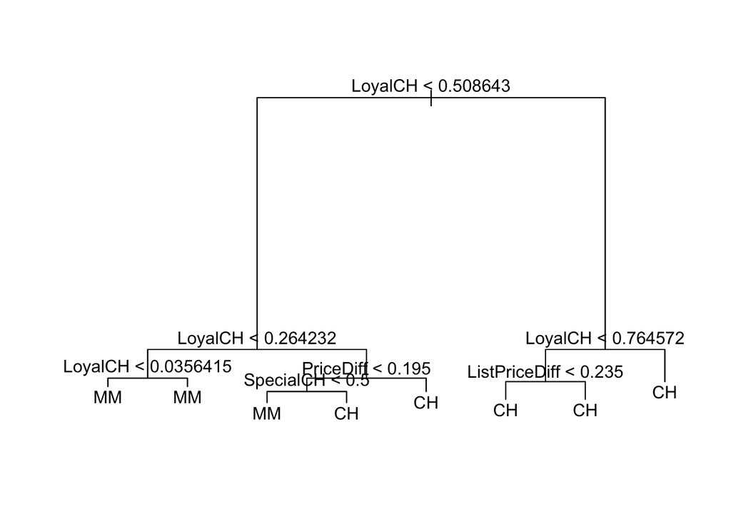

```r
plot(tree.OJ)
text(tree.OJ,pretty=0)
```

The most important factor is having a loyalty to CH of less than ~.509. Loyalty to the brand is all over the place. If your loyalty is less thatn .5 but more than .26, then price difference and the presence of a special on CH makes a difference. (e) Predict the response on the test data, and produce a confusion matrix comparing the test labels to the predicted test labels. What is the test error rate?

```r
pred.OJ = predict(tree.OJ,newdata=OJ.test,type = "class")
table(pred.OJ,OJ.test$Purchase)
```

```
##
## pred.OJ  CH  MM
##      CH 147  49
##      MM  12  62
```

```r
1-mean(pred.OJ==OJ.test$Purchase)
```

```
## [1] 0.2259259
```

The test error rate is about 23%. (f) Apply the cv.tree() function to the training set in order to determine the optimal tree size.

```r
set.seed(3)
cv.OJ = cv.tree(tree.OJ,FUN=prune.misclass)
cv.OJ
```

```
## $size
## [1] 8 5 2 1
##
## $dev
## [1] 151 151 157 306
##
## $k
## [1]       -Inf   0.000000   4.666667 160.000000
##
## $method
## [1] "misclass"
##
## attr(,"class")
## [1] "prune"         "tree.sequence"
```

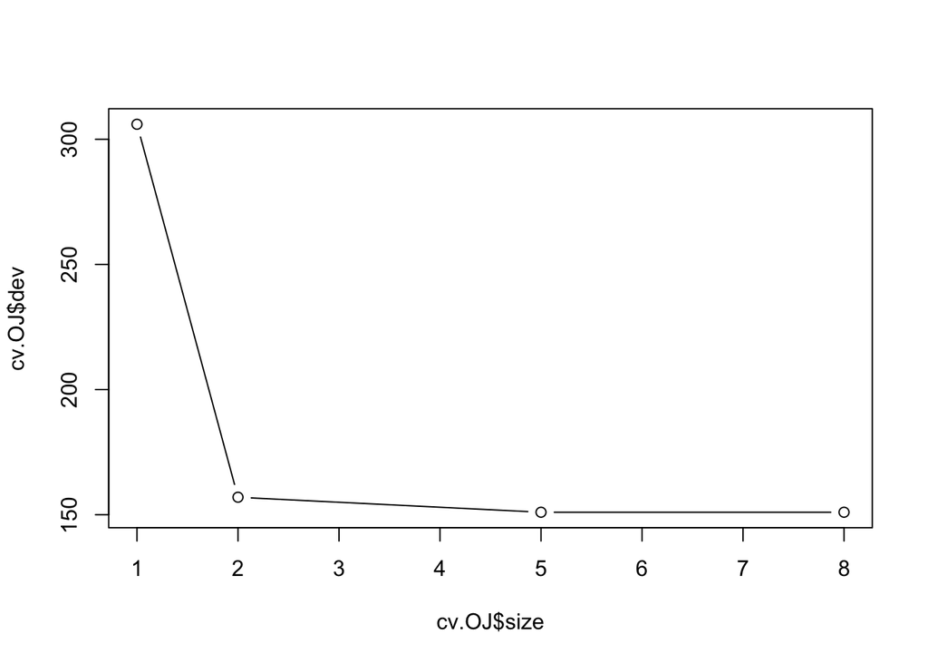

```r
plot(cv.OJ$size,cv.OJ$dev,type="b")
```

A tree with 5 nodes does the best, tieing with a tree with 8 nodes. (i) Produce a pruned tree corresponding to the optimal tree size obtained using cross-validation. If cross-validation does not lead to selection of a pruned tree, then create a pruned tree with five terminal nodes. (j) Compare the training error rates between the pruned and un- pruned trees. Which is higher?

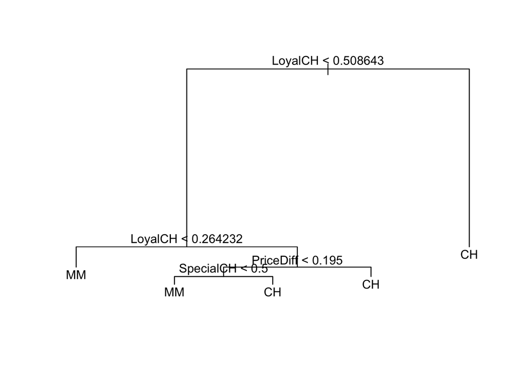

```r
prune.OJ = prune.misclass(tree.OJ,best=5)
plot(prune.OJ)
text(prune.OJ,pretty=0)
```

```r
summary(prune.OJ)
```

```
##
## Classification tree:
## snip.tree(tree = tree.OJ, nodes = 3:4)
## Variables actually used in tree construction:
## [1] "LoyalCH"   "PriceDiff" "SpecialCH"
## Number of terminal nodes:  5
## Residual mean deviance:  0.8256 = 656.4 / 795
## Misclassification error rate: 0.165 = 132 / 800
```

```r
summary(tree.OJ)
```

```
##
## Classification tree:
## tree(formula = Purchase ~ ., data = OJ.train)
## Variables actually used in tree construction:
## [1] "LoyalCH"       "PriceDiff"     "SpecialCH"     "ListPriceDiff"
## Number of terminal nodes:  8
## Residual mean deviance:  0.7305 = 578.6 / 792
## Misclassification error rate: 0.165 = 132 / 800
```

The training misclassification error rate for both trees is .165. (k) Compare the test error rates between the pruned and unpruned trees. Which is higher?

```r
pred.prune.OJ = predict(prune.OJ,newdata=OJ.test,type="class")
table(pred.prune.OJ,OJ.test$Purchase)
```

```
##
## pred.prune.OJ  CH  MM
##            CH 147  49
##            MM  12  62
```

```r
mean(pred.prune.OJ != OJ.test$Purchase)
```

```
## [1] 0.2259259
```

```r
mean(pred.OJ != OJ.test$Purchase)
```

```
## [1] 0.2259259
```

The test error rate also appears to be exactly the same: .226.

### 8.4.10

10. We now use boosting to predict Salary in the Hitters data set.
1. Remove the observations for whom the salary information is unknown, and then log-transform the salaries.

```r
data("Hitters")
attach(Hitters)

Hitters = Hitters[!is.na(Hitters$Salary),]
Hitters$Salary = log(Hitters$Salary)
```

2. Create a training set consisting of the first 200 observations, and a test set consisting of the remaining observations.

```r
train = sample(1:nrow(Hitters),200)
Hitters.train = Hitters[train,]
Hitters.test = Hitters[-train,]
```

3. Perform boosting on the training set with 1,000 trees for a range of values of the shrinkage parameter λ. Produce a plot with different shrinkage values on the x-axis and the corresponding training set MSE on the y-axis.
4. Produce a plot with different shrinkage values on the x-axis and the corresponding test set MSE on the y-axis.

```r
library(gbm)
set.seed(1)

shrinkGrid = seq(.1,.001,by=-.001)
shrinkGrid
```

```
##   [1] 0.100 0.099 0.098 0.097 0.096 0.095 0.094 0.093 0.092 0.091 0.090
##  [12] 0.089 0.088 0.087 0.086 0.085 0.084 0.083 0.082 0.081 0.080 0.079
##  [23] 0.078 0.077 0.076 0.075 0.074 0.073 0.072 0.071 0.070 0.069 0.068
##  [34] 0.067 0.066 0.065 0.064 0.063 0.062 0.061 0.060 0.059 0.058 0.057
##  [45] 0.056 0.055 0.054 0.053 0.052 0.051 0.050 0.049 0.048 0.047 0.046
##  [56] 0.045 0.044 0.043 0.042 0.041 0.040 0.039 0.038 0.037 0.036 0.035
##  [67] 0.034 0.033 0.032 0.031 0.030 0.029 0.028 0.027 0.026 0.025 0.024
##  [78] 0.023 0.022 0.021 0.020 0.019 0.018 0.017 0.016 0.015 0.014 0.013
##  [89] 0.012 0.011 0.010 0.009 0.008 0.007 0.006 0.005 0.004 0.003 0.002
## [100] 0.001
```

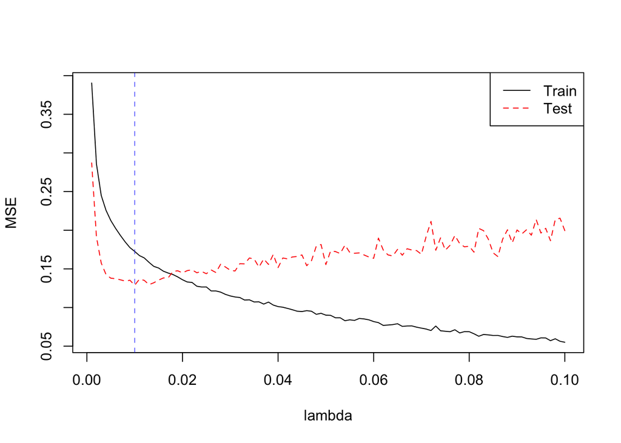

```r
MSE = matrix(NA,nrow=length(shrinkGrid),ncol=2)
for(i in 1:length(shrinkGrid)){
   lambda = shrinkGrid[i]
   boost.hitters = gbm(Salary~.,data=Hitters.train,distribution="gaussian",n.trees=1000,shrinkage=lambda)
   boost.pred.train = predict(boost.hitters,Hitters.train,n.trees=1000)
   boost.pred.test = predict(boost.hitters,Hitters.test,n.trees=1000)
   train.MSE = mean((boost.pred.train - Hitters.train$Salary)^2)
   test.MSE = mean((boost.pred.test - Hitters.test$Salary)^2)
   MSE[i,1] = train.MSE
   MSE[i,2] = test.MSE
}

best.lambda = shrinkGrid[which.min(MSE[,2])]
matplot(x=shrinkGrid,y=MSE,type="l",xlab="lambda",ylab="MSE")
legend("topright",legend = c("Train","Test"),col=c("black","red"),lty=c(1,2))
abline(v=best.lambda,col="blue",lty=2,lwd=.5)
```

```r
print(paste0("Best Test MSE: ", MSE[which.min(MSE[,2]),2]))
```

```
## [1] "Best Test MSE: 0.128831506319219"
```

5. Compare the test MSE of boosting to the test MSE that results from applying two of the regression approaches seen in Chapters 3 and 6. I’ll use ridge regression and lasso methods, with the lambda tuning parameter for these methods chosen by cross validation on the training set. We’ll then make predictions and calculate the test MSE for comparison with our boosting method above.

```r
library(glmnet)
x.hitters.train = model.matrix(Salary~.,Hitters.train)[,-1]
x.hitters.test = model.matrix(Salary~.,Hitters.test)[,-1]
y.hitters.train = Hitters.train$Salary
y.hitters.test = Hitters.test$Salary

lambdaGrid = 10^seq(10,-2,length=100)

cv.ridge = cv.glmnet(x.hitters.train,y.hitters.train,alpha=0)
bestlam.ridge = cv.ridge$lambda.min
cv.lasso = cv.glmnet(x.hitters.train,y.hitters.train,alpha=1)
bestlam.lasso = cv.lasso$lambda.min
ridge.hitters = glmnet(x.hitters.train,y.hitters.train,alpha=0,lambda=lambdaGrid)
lasso.hitters = glmnet(x.hitters.train,y.hitters.train,alpha=1,lambda=lambdaGrid)

ridge.pred = predict(ridge.hitters,s=bestlam.ridge,newx=x.hitters.test)
lasso.pred = predict(lasso.hitters,s=bestlam.lasso,newx=x.hitters.test)

ridge.MSE.test = mean((ridge.pred - y.hitters.test)^2)
lasso.MSE.test = mean((lasso.pred - y.hitters.test)^2)

print(paste0("Boost Test MSE: ", MSE[which.min(MSE[,2]),2]))
```

```
## [1] "Boost Test MSE: 0.128831506319219"
```

```r
print(paste0("Ridge Test MSE: ", ridge.MSE.test))
```

```
## [1] "Ridge Test MSE: 0.318981948354656"
```

```r
print(paste0("Lasso Test MSE: ", lasso.MSE.test))
```

```
## [1] "Lasso Test MSE: 0.317031096962559"
```

Boosting appears to have outperformed both ridge regression and the lasso on the test set. (f) Which variables appear to be the most important predictors in the boosted model?

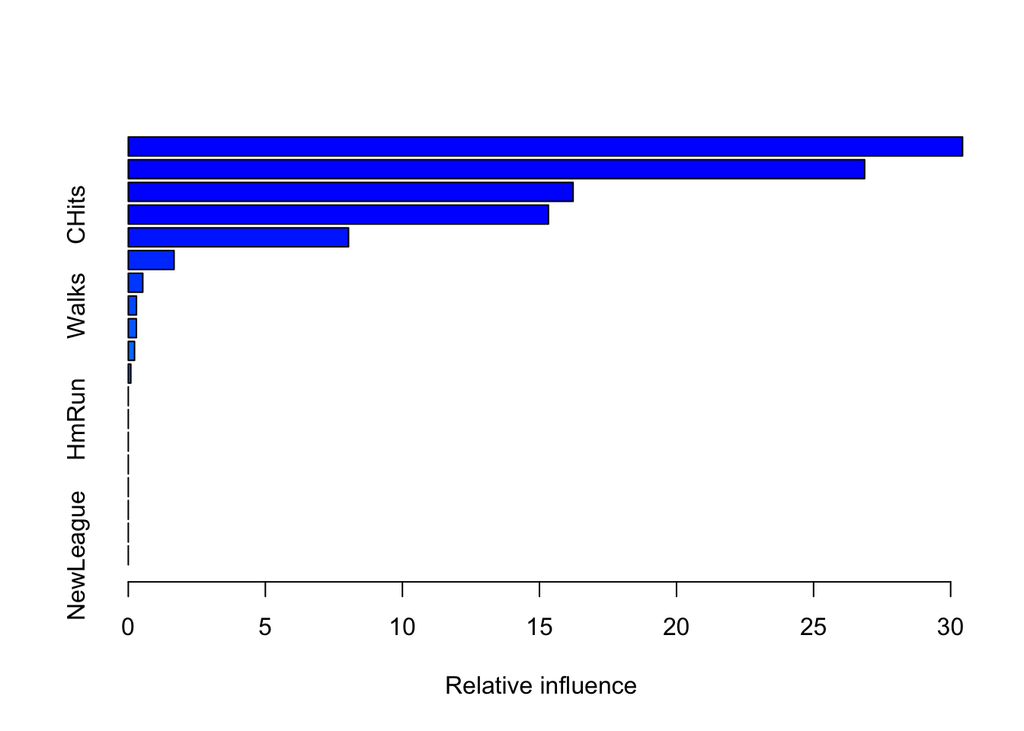

```
##                 var     rel.inf
## CRuns         CRuns 30.43483150
## CAtBat       CAtBat 26.86289260
## CWalks       CWalks 16.22708349
## CHits         CHits 15.32802093
## CRBI           CRBI  8.03449413
## CHmRun       CHmRun  1.67004152
## Hits           Hits  0.52869588
## Walks         Walks  0.29831928
## Years         Years  0.29593717
## RBI             RBI  0.22783027
## Runs           Runs  0.09185321
## AtBat         AtBat  0.00000000
## HmRun         HmRun  0.00000000
## League       League  0.00000000
## Division   Division  0.00000000
## PutOuts     PutOuts  0.00000000
## Assists     Assists  0.00000000
## Errors       Errors  0.00000000
## NewLeague NewLeague  0.00000000
```

```r
summary(boost.hitters)
```

7. Now apply bagging to the training set. What is the test set MSE for this approach?

```r
library(randomForest)

bag.hitters = randomForest(Salary~.,data=Hitters.train,ntree=1000,mtry=19,importance=TRUE)
bag.pred = predict(bag.hitters,newdata=Hitters.test)

bag.MSE.test = mean((bag.pred - Hitters.test$Salary)^2)
print(paste0("Bagging Test MSE: ",bag.MSE.test))
```

```
## [1] "Bagging Test MSE: 0.112526159412215"
```

Bagging appears to have slightly outperformed boosting, ridge, and lasso.

### 8.4.11